# R Notebook

# Lexical Diversity

## Import the libraries

To Perfom the Natural Language processing we need to import the necessary libraries

```r
#install.packages(c("xml2", "tidyverse", "quanteda"))
#tinytex::install_tinytex()
library(xml2)
library(rmarkdown)
library(textstem)
library(spacyr)
library(stringr)
library(readr)
library(quanteda)
library(readtext)
library(quanteda.textstats)
library(tokenizers)
library(tidytext)
library(tibble)
library(dplyr)
library(ggplot2)
```

We set the working directory to the folder containing our XML files: cleaned_reagan_speeches.xml and cleaned_trump_speeches.xml

```r
setwd("C:/Users/leo_m/Desktop/Corpus_Analysis/Final_Project/Reagan_Trump")
```

## XML to Data Frame

We transformed the XML files into a data frame, converting the XML nodes into table columns using the xml2 library.

```r
parse_speeches <- function(file_path, speaker) {
  # Read XML file
  xml_data <- read_xml(file_path)

  # Extract all speech nodes
  speeches <- xml_find_all(xml_data, "//speech")

  # Extract each node as a vector
  titles <- xml_text(xml_find_all(speeches, "title"))
  dates <- xml_text(xml_find_all(speeches, "date"))
  links <- xml_text(xml_find_all(speeches, "link"))
  texts <- xml_text(xml_find_all(speeches, "text"))

  # Create a data frame
  df <- tibble(
    speaker = speaker,
    title = titles,
    date = dates,
    link = links,
    text = texts
  )

  return(df)
}
```

### Create a Data Frame of the speeches

We create a data frame for each president and the we combine both in one data frame speeches_df

```r
# Parse Reagan speeches
reagan_df <- parse_speeches("cleaned_reagan_speeches.xml", "Reagan")

# Parse Trump speeches
trump_df <- parse_speeches("cleaned_trump_speeches.xml", "Trump")

# Combine into one data frame
speeches_df <- bind_rows(reagan_df, trump_df)

#Preview of the data frame
head(speeches_df)
```

| speaker | title | date | link | text |
| --- | --- | --- | --- | --- |
| Reagan | Address on Behalf of Senator Barry Goldwater: "A Time for Choosing" | October 27, 1964 | https://www.presidency.ucsb.edu/documents/address-behalf-senator-barry-goldwater-time-for-choosing | Thank you very much. Thank you and good evening. The sponsor has been identified, but unlike most television programs, the performer hasn't been provided with a script. As a matter of fact, I have bee… |
| Reagan | Remarks Announcing Candidacy for the Republican Presidential Nomination | November 13, 1979 | https://www.presidency.ucsb.edu/documents/remarks-announcing-candidacy-for-the-republican-presidential-nomination-2 | Good evening. I am here tonight to announce my intention to seek the Republican nomination for President of the United States.\nI'm sure that each of us has seen our country from a number of viewpoint… |
| Reagan | Address Accepting the Presidential Nomination at the Republican National Convention in Detroit | July 17, 1980 | https://www.presidency.ucsb.edu/documents/address-accepting-the-presidential-nomination-the-republican-national-convention-detroit | Mr. Chairman, Mr. Vice President to be, this convention, my fellow citizens of this great nation:\nWith a deep awareness of the responsibility conferred by your trust, I accept your nomination for the… |
| Reagan | Remarks to Delgates at the Republican National Convention in Detroit Announcing the Selection of George Bush as Vice Presidential Running Mate | July 17, 1980 | https://www.presidency.ucsb.edu/documents/remarks-delgates-the-republican-national-convention-detroit-announcing-the-selection | Thank you. The delegates of this convention, you ladies and gentlemen and those who are viewing, I know that I am breaking precedent to come here tonight; and I assure you at this late hour I'm not go… |
| Reagan | Address to the Veterans of Foreign Wars Convention in Chicago | August 18, 1980 | https://www.presidency.ucsb.edu/documents/address-the-veterans-foreign-wars-convention-chicago | Thank you Commander Vanderclute.\nFour weeks ago, I was deeply honored to go before a national convention of my party and accept the greatest honor they can bestow: their nomination for the Presidency… |
| Reagan | Remarks at Liberty State Park, Jersey City, New Jersey | September 01, 1980 | https://www.presidency.ucsb.edu/documents/remarks-liberty-state-park-jersey-city-new-jersey | It is fitting that on Labor Day, we meet beside the waters of New York harbor, with the eyes of Miss Liberty on our gathering and in the words of the poet whose lines are inscribed at her feet, "The a… |

```r
dim(speeches_df)
```

```
[1] 370   5
```

```r
# Count the number of speeches for each speaker
speech_counts <- speeches_df %>%
  group_by(speaker) %>%
  summarise(count = n())
print(speech_counts)
```

| speaker | count |
| --- | --- |
| Reagan | 139 |
| Trump | 231 |

### Balancing same number of speeches for each President

After scraping, there were more Donald Trump speeches available in the American Presidency Project. To ensure a balanced dataset for comparison, we randomly selected 139 speeches for Donald Trump using sample_n(), matching the number of speeches available for Ronald Reagan. We also check for any duplicates

```r
# Set a seed for reproducibility
set.seed(123)  # Ensures consistent random sampling

# Filter Reagan speeches (keep all) and sample 139 Trump speeches
balanced_speeches_df <- speeches_df %>%
  filter(speaker == "Reagan") %>%
  bind_rows(
    speeches_df %>%
      filter(speaker == "Trump") %>%
      sample_n(size = 139)
  )
# Check the number of speeches per speaker
balanced_counts <- balanced_speeches_df %>%
  group_by(speaker) %>%
  summarise(count = n())
print(balanced_counts)
```

| speaker | count |
| --- | --- |
| Reagan | 139 |
| Trump | 139 |

```r
# Inspect the data frame (Show 5 random rows)

print(balanced_speeches_df[sample(nrow(balanced_speeches_df), 5), ])
```

| speaker | title | date | link | text |
| --- | --- | --- | --- | --- |
| Trump | Remarks at a "Make America Great Again" Rally in Huntington, West Virginia | November 02, 2018 | https://www.presidency.ucsb.edu/documents/remarks-make-america-great-again-rally-huntington-west-virginia-0 | Wow, thank you so much. Hello, West Virginia. What a place. \nYou know, we only won West Virginia by 42 points last time. \n42 points. You know what that is? That's like did anyone ever hear of 42 poi… |
| Reagan | Remarks at a Reagan-Bush Rally in Corpus Christi, Texas | October 02, 1984 | https://www.presidency.ucsb.edu/documents/remarks-reagan-bush-rally-corpus-christi-texas | Thank you very much, and muchas gracias.\nI'm very proud to have been introduced by your Congressman, but I hope soon to be, if you do what's right, your Senator, Phil Gramm.\nWell, it's great to be b… |
| Reagan | Remarks at a Reagan-Bush Rally in Little Rock, Arkansas | November 03, 1984 | https://www.presidency.ucsb.edu/documents/remarks-reagan-bush-rally-little-rock-arkansas | Thank you. Thank you very much.\nThat's what I came here to talk to you about. Thank you very much. Thank you, ladies and gentlemen. It's wonderful to be in Arkansas. And if I have my history correct,… |
| Reagan | Remarks at a Reagan-Bush Rally in Sacramento, California | November 05, 1984 | https://www.presidency.ucsb.edu/documents/remarks-reagan-bush-rally-sacramento-california | Thank you. And thank you, Governor Deukmejian, Senator Wilson, Congressmen Chappie and Shumway. It sure feels great to be home.\nYou know, there's a picture on the wall inside there that looks somethi… |
| Trump | Remarks at a Rally in Selma, North Carolina | April 09, 2022 | https://www.presidency.ucsb.edu/documents/remarks-rally-selma-north-carolina | Wow, thank you very much. Thank you very much, that's great. This is a big crowd of people This is nice. Thank you Selma. We love to be in Selma, and we've had some great experiences here and we've ha… |

```r
# Check for duplicate titles
duplicate_titles <- balanced_speeches_df %>%
  group_by(title) %>%
  summarise(count = n()) %>%
  filter(count > 1)
print(duplicate_titles)
```

| title | count |
| --- | --- |
| Remarks at a Campaign Rally in Greensboro, North Carolina | 2 |
| Remarks at a Reagan-Bush Rally in San Diego, California | 2 |
| Remarks at a Republican Campaign Rally in San Diego, California | 2 |

Even when the titles appear similar, the dates differ, indicating that the events were the same but the speeches were delivered in different contexts.

```r
# Create root node
root <- xml_new_root("speeches")

# Loop over speeches
for (i in seq_len(nrow(balanced_speeches_df))) {

  speech_node <- xml_add_child(root, "speech")

  xml_add_child(speech_node, "speaker",
                balanced_speeches_df$speaker[i])

  xml_add_child(speech_node, "title",
                balanced_speeches_df$title[i])

  xml_add_child(speech_node, "date",
                balanced_speeches_df$date[i])

  xml_add_child(speech_node, "text",
                balanced_speeches_df$text[i])



}
write_xml(root, "trump_139_selected_speeches.xml")
```

## Creating a Quanteda Corpus

We first added a unique ID to each speech using mutate() and sprintf(“%03d”, row_number()), creating IDs like 001, 002, etc. Then, we built a quanteda corpus with corpus(), specifying the text column (text_field = “text”) and the document ID (docid_field = “unique_id”). This allows efficient text analysis. Finally, we checked the corpus structure with print(), summary(), and head(docnames()) to confirm the documents were correctly labeled.

```r
balanced_speeches_df <- balanced_speeches_df %>%
  mutate(unique_id = sprintf("%03d", row_number()))
# Create a quanteda corpus
speeches_corpus <- corpus(balanced_speeches_df,
                          text_field = "text",
                          docid_field = "unique_id")
#Check the corpus structure
print(speeches_corpus)
```

```
Corpus consisting of 278 documents and 4 docvars.
001 :
"Thank you very much. Thank you and good evening. The sponsor..."

002 :
"Good evening. I am here tonight to announce my intention to ..."

003 :
"Mr. Chairman, Mr. Vice President to be, this convention, my ..."

004 :
"Thank you. The delegates of this convention, you ladies and ..."

005 :
"Thank you Commander Vanderclute. Four weeks ago, I was deepl..."

006 :
"It is fitting that on Labor Day, we meet beside the waters o..."

[ reached max_ndoc ... 272 more documents ]
```

```r
speeches_corpus_df <- summary(speeches_corpus)
head(docnames(speeches_corpus))
```

```
[1] "001" "002" "003" "004" "005" "006"
```

### Tokenization( Token-lenght based Method)

Then We generated a summary of the corpus using summary(speeches_corpus, n = 5), which shows the first five documents. Then, we tokenized the corpus with quanteda::tokens(), by default it splits the text into individual words for analysis.

We extracted the document names with docnames() and the speakers from the document variables using docvars(), storing them in speakers_vec and naming them according to their document IDs. This links each speech to its speaker.

```r
# Summary of the corpus
summary(speeches_corpus, n = 5)  # Shows first 5 documents
```

```
Corpus consisting of 278 documents, showing 5 documents:

 Text Types Tokens Sentences speaker
  001  1387   5204       225  Reagan
  002  1171   4044       168  Reagan
  003  1390   5227       200  Reagan
  004   195    436        19  Reagan
  005  1294   4355       191  Reagan
                                                                                                                                          title
                                                                            Address on Behalf of Senator Barry Goldwater: "A Time for Choosing"
                                                                        Remarks Announcing Candidacy for the Republican Presidential Nomination
                                                 Address Accepting the Presidential Nomination at the Republican National Convention in Detroit
 Remarks to Delgates at the Republican National Convention in Detroit Announcing the Selection of George Bush as Vice Presidential Running Mate
                                                                                  Address to the Veterans of Foreign Wars Convention in Chicago
              date
  October 27, 1964
 November 13, 1979
     July 17, 1980
     July 17, 1980
   August 18, 1980
                                                                                                                               link
                                 https://www.presidency.ucsb.edu/documents/address-behalf-senator-barry-goldwater-time-for-choosing
                https://www.presidency.ucsb.edu/documents/remarks-announcing-candidacy-for-the-republican-presidential-nomination-2
 https://www.presidency.ucsb.edu/documents/address-accepting-the-presidential-nomination-the-republican-national-convention-detroit
     https://www.presidency.ucsb.edu/documents/remarks-delgates-the-republican-national-convention-detroit-announcing-the-selection
                                     https://www.presidency.ucsb.edu/documents/address-the-veterans-foreign-wars-convention-chicago
```

```r
speeches_tokens <- quanteda:: tokens(speeches_corpus)

docnames_vec <- docnames(speeches_tokens)
speakers_vec <- docvars(speeches_tokens, "speaker")
names(speakers_vec) <- docnames_vec
```

### Overall Token counts

```r
library(quanteda)
library(dplyr)

# Tokenize the corpus (word tokens)
speeches_tokens <- quanteda::tokens(
  speeches_corpus,
  remove_punct = TRUE
) %>%
  tokens_tolower()

total_tokens <- sum(ntoken(speeches_tokens))
print(total_tokens)
```

```
[1] 1141610
```

```r
# Sentence tokenization (leave this unchanged)
speeches_sentences <- quanteda::tokens(
  speeches_corpus,
  what = "sentence"
)

total_sentences <- sum(ntoken(speeches_sentences))
print(total_sentences)
```

```
[1] 92808
```

```r
# Tokens and Sentences per document
token_counts <- ntoken(speeches_tokens)
sentence_counts <- ntoken(speeches_sentences)

# Document-level metadata
doc_info <- docvars(speeches_corpus)

# Combine counts with metadata
count_data <- data.frame(
  speaker   = doc_info$speaker,
  tokens    = token_counts,
  sentences = sentence_counts
)

# Aggregate totals by speaker
aggregate_stats <- count_data %>%
  group_by(speaker) %>%
  summarise(
    total_tokens     = sum(tokens),
    avg_tokens       = mean(tokens),
    sd_tokens        = sd(tokens),
    total_sentences  = sum(sentences),
    avg_sentences    = mean(sentences),
    sd_sentences     = sd(sentences),
    n_speeches       = n()
  )

print(aggregate_stats)
```

| speaker | total_tokens | avg_tokens | sd_tokens | total_sentences | avg_sentences | sd_sentences | n_speeches |
| --- | --- | --- | --- | --- | --- | --- | --- |
| Reagan | 364326 | 2621.050 | 1198.000 | 20087 | 144.5108 | 70.49467 | 139 |
| Trump | 777284 | 5591.971 | 3328.883 | 72721 | 523.1727 | 358.38996 | 139 |

```r
NA
NA
NA
```

## Chunking Strategy. Creatin a Corpus of Chunks.

As we can see above, the speeches vary considerably in length. To ensure greater uniformity and comparability in the linguistic analysis, it was necessary to split the texts into smaller units. For this purpose, we used the quanteda package and its chunk_text function to divide the speeches into segments of 512 words each, and lowercase the words.

```r
library(quanteda)
library(dplyr)
library(stringr)

set.seed(123)

# =====================================================
# 1. Chunk speeches into ~512-word segments
# =====================================================

speeches_chunked <- chunk_text(
  speeches_corpus,
  chunk_size   = 512,
  strip_punct  = FALSE,
  lowercase    = TRUE
)

speeches_chunked <- unlist(speeches_chunked)

chunked_df <- data.frame(
  unique_id = names(speeches_chunked),
  text      = speeches_chunked,
  stringsAsFactors = FALSE
)

chunked_df <- chunked_df %>%
  mutate(original_doc = str_remove(unique_id, "-\\d+$"))

# =====================================================
# 2. Attach metadata from original corpus
# =====================================================

original_meta <- data.frame(
  original_doc = docnames(speeches_corpus),
  speaker      = docvars(speeches_corpus, "speaker"),
  title         = docvars(speeches_corpus, "title"),
  date         = docvars(speeches_corpus, "date"),
  link         = docvars(speeches_corpus, "link"),
  stringsAsFactors = FALSE
)

chunked_df <- chunked_df %>%
  left_join(original_meta, by = "original_doc")

# =====================================================
# 3. Create chunked corpus
# =====================================================

corpus_chunked <- corpus(
  chunked_df,
  text_field  = "text",
  docid_field = "unique_id"
)

# =====================================================
# 4. Tokenize ONCE and compute token counts
# =====================================================

toks_all <- tokens(
  corpus_chunked,
  remove_punct   = TRUE,
  remove_numbers = TRUE,
  remove_symbols = TRUE
)

chunked_df$ntokens <- ntoken(toks_all)

# =====================================================
# 5. Drop empty and short chunks (CRITICAL STEP)
# =====================================================

MIN_TOKENS <- 400

chunked_df_clean <- chunked_df %>%
  filter(ntokens >= MIN_TOKENS)



chunks_per_speaker <- chunked_df_clean %>%
  count(speaker, name = "n_chunks")

print(chunks_per_speaker)
```

| speaker | n_chunks |
| --- | --- |
| Reagan | 767 |
| Trump | 1632 |

```r
NA
```

### Balancing chunks per Speaker

As we see Trump’speeches are longer they produce more chunks it is necessary to balance the same number of chunks for each speaker

```r
set.seed(123)
# =====================================================
# 6. Balance speakers AFTER cleaning
# =====================================================

n_min <- chunked_df_clean %>%
  count(speaker) %>%
  summarise(min(n)) %>%
  pull()

balanced_df <- chunked_df_clean %>%
  group_by(speaker) %>%
  slice_sample(n = n_min) %>%
  ungroup()

# =====================================================
# 7. Create final balanced corpus
# =====================================================

corpus_balanced <- corpus(
  balanced_df,
  text_field  = "text",
  docid_field = "unique_id"
)

# =====================================================
# 8. Final verification (should be PERFECT)
# =====================================================

toks_balanced <- tokens(
  corpus_balanced,
  remove_punct   = TRUE,
  remove_numbers = TRUE,
  remove_symbols = TRUE
)

cat("\nDocuments per speaker:\n")
```

```
Documents per speaker:
```

```r
print(docvars(corpus_balanced) %>% count(speaker))
```

| speaker | n |
| --- | --- |
| Reagan | 767 |
| Trump | 767 |

```r
cat("\nToken count summary:\n")
```

```
Token count summary:
```

```r
print(summary(ntoken(toks_balanced)))
```

```
   Min. 1st Qu.  Median    Mean 3rd Qu.    Max.
  400.0   423.0   435.0   433.7   445.0   472.0
```

```r
cat("\nEmpty documents:\n")
```

```
Empty documents:
```

```r
print(sum(ntoken(toks_balanced) == 0))
```

```
[1] 0
```

### Creating a balanced Corpus of 767 chunks for each speaker

When we created the chunked corpus every chunk also received an identifier in the format 001-01, where the first three digits correspond to the speech ID and the second part indicates the chunk number.

```r
set.seed(123)

# =====================================================
# 1. Chunk speeches into ~512-word segments
# =====================================================
speeches_chunked <- chunk_text(
  speeches_corpus,
  chunk_size   = 512,
  strip_punct = FALSE,
  lowercase   = TRUE
)

speeches_chunked <- unlist(speeches_chunked)

chunked_df <- data.frame(
  unique_id = names(speeches_chunked),
  text      = speeches_chunked,
  stringsAsFactors = FALSE
)

chunked_df <- chunked_df %>%
  mutate(original_doc = str_remove(unique_id, "-\\d+$"))

# =====================================================
# 2. Attach metadata from original corpus
# =====================================================
original_meta <- data.frame(
  original_doc = docnames(speeches_corpus),
  speaker      = docvars(speeches_corpus, "speaker"),
  title        = docvars(speeches_corpus, "title"),
  date         = docvars(speeches_corpus, "date"),
  link         = docvars(speeches_corpus, "link"),
  stringsAsFactors = FALSE
)

chunked_df <- chunked_df %>%
  left_join(original_meta, by = "original_doc")

# =====================================================
# 3. Create chunked corpus
# =====================================================
corpus_chunked <- corpus(
  chunked_df,
  text_field  = "text",
  docid_field = "unique_id"
)

# =====================================================
# 4. Tokenize ONCE and compute token counts
# =====================================================
toks_all <- tokens(
  corpus_chunked,
  remove_punct   = TRUE,
  remove_numbers = TRUE,
  remove_symbols = TRUE
)

chunked_df$ntokens <- ntoken(toks_all)

# =====================================================
# 5. Drop empty and short chunks (CRITICAL STEP)
# =====================================================
MIN_TOKENS <- 400

chunked_df_clean <- chunked_df %>%
  filter(ntokens >= MIN_TOKENS)

chunks_per_speaker <- chunked_df_clean %>%
  count(speaker, name = "n_chunks")

print(chunks_per_speaker)
```

| speaker | n_chunks |
| --- | --- |
| Reagan | 767 |
| Trump | 1632 |

```r
set.seed(123)

# =====================================================
# 6. Balance speakers AFTER cleaning
# =====================================================
n_min <- chunked_df_clean %>%
  count(speaker) %>%
  summarise(min_n = min(n)) %>%
  pull(min_n)

balanced_df <- chunked_df_clean %>%
  group_by(speaker) %>%
  slice_sample(n = n_min) %>%
  ungroup()

# =====================================================
# 7. Create final balanced corpus
# =====================================================
corpus_balanced <- corpus(
  balanced_df,
  text_field  = "text",
  docid_field = "unique_id"
)

# =====================================================
# 8. Removing punctuation, Number, Symbols, Lowercasing
# =====================================================
toks_balanced <- tokens(
  corpus_balanced,
  remove_punct   = TRUE,
  remove_numbers = TRUE,
  remove_symbols = TRUE
)

toks_balanced <- tokens_tolower(toks_balanced)

cat("\nDocuments per speaker:\n")
```

```
Documents per speaker:
```

```r
print(docvars(corpus_balanced) %>% count(speaker))
```

| speaker | n |
| --- | --- |
| Reagan | 767 |
| Trump | 767 |

```r
cat("\nToken count summary:\n")
```

```
Token count summary:
```

```r
print(summary(ntoken(toks_balanced)))
```

```
   Min. 1st Qu.  Median    Mean 3rd Qu.    Max.
  400.0   423.0   435.0   433.7   445.0   472.0
```

### Measuring Word lenghts

```r
word_lengths <- lapply(toks_balanced, nchar)
word_length_df <- data.frame(
  speaker = rep(docvars(corpus_balanced, "speaker"),
                lengths(word_lengths)),
  word_length = unlist(word_lengths),
  stringsAsFactors = FALSE
)
avg_word_length <- word_length_df %>%
  group_by(speaker) %>%
  summarise(
    avg_word_length = mean(word_length),
    sd_word_length  = sd(word_length),
    n_words         = n()
  )
print(avg_word_length)
```

| speaker | avg_word_length | sd_word_length | n_words |
| --- | --- | --- | --- |
| Reagan | 4.422655 | 2.320125 | 339196 |
| Trump | 4.312493 | 2.189462 | 326154 |

## Diversity Metrics with Stopwords

### Calculating TTR

```r
lex_div_df <- data.frame(
  doc_id   = docnames(toks_balanced),
  speaker  = docvars(corpus_balanced, "speaker"),
  tokens   = ntoken(toks_balanced),
  types    = ntype(toks_balanced)
)

lex_div_df <- lex_div_df %>%
  mutate(
    TTR = types / tokens
  )
```

### Calculating MATTR

```r
lex_div_df$MATTR <- textstat_lexdiv(
  toks_balanced,
  measure = "MATTR",
  MATTR_window = 100
)$MATTR
```

### Summary of TTR and MATTR

```r
lex_div_summary <- lex_div_df %>%
  group_by(speaker) %>%
  summarise(
    n_docs    = n(),
    avg_TTR   = mean(TTR),
    sd_TTR    = sd(TTR),
    min_TTR   = min(TTR),
    max_TTR   = max(TTR),
    avg_MATTR = mean(MATTR),
    sd_MATTR  = sd(MATTR),
    min_MATTR = min(MATTR),
    max_MATTR = max(MATTR)
  )

print(lex_div_summary)
```

[output not shown]

## Diversity Metrics no Stopwords

Removing stopwords is important when measuring lexical diversity because high-frequency function words (such as the, and, of, to) occur in almost every sentence regardless of speaker, topic, or rhetorical strategy. If they are retained, they artificially inflate token counts while contributing very little to lexical variation. This can distort measures like TTR and MATTR by lowering apparent diversity and masking meaningful stylistic differences.

```r
# =====================================================
# Lexical Diversity (TTR & MATTR) WITHOUT stopwords
# Minimal-change solution (Solution 2)
# =====================================================

library(quanteda)
library(dplyr)

set.seed(123)

# -----------------------------------------------------
# 1. Tokenize balanced corpus
# -----------------------------------------------------
toks_balanced_nostop <- tokens(
  corpus_balanced,
  remove_punct   = TRUE,
  remove_numbers = TRUE,
  remove_symbols = TRUE
)

toks_balanced_nostop <- tokens_tolower(toks_balanced_nostop)

# -----------------------------------------------------
# 2. Remove stopwords
# -----------------------------------------------------
toks_balanced_nostop <- tokens_remove(
  toks_balanced_nostop,
  pattern = stopwords("en")
)

# -----------------------------------------------------
# 3. Drop empty documents
# -----------------------------------------------------
toks_balanced_nostop <- toks_balanced_nostop[
  ntoken(toks_balanced_nostop) > 0
]

# -----------------------------------------------------
# 4. Subset speaker metadata to match filtered tokens
# -----------------------------------------------------
speaker_vec <- docvars(corpus_balanced, "speaker")
names(speaker_vec) <- docnames(corpus_balanced)
speaker_vec <- speaker_vec[docnames(toks_balanced_nostop)]

# -----------------------------------------------------
# 5. Compute TTR
# -----------------------------------------------------
lex_div_df_nostop <- data.frame(
  doc_id  = docnames(toks_balanced_nostop),
  speaker = speaker_vec,
  tokens  = ntoken(toks_balanced_nostop),
  types   = ntype(toks_balanced_nostop),
  stringsAsFactors = FALSE
)

lex_div_df_nostop <- lex_div_df_nostop %>%
  mutate(TTR = types / tokens)

# -----------------------------------------------------
# 6. Compute MATTR
# -----------------------------------------------------
lex_div_df_nostop$MATTR <- textstat_lexdiv(
  toks_balanced_nostop,
  measure = "MATTR",
  MATTR_window = 100
)$MATTR

# -----------------------------------------------------
# 7. Speaker-level summary
# -----------------------------------------------------
lex_div_summary_nostop <- lex_div_df_nostop %>%
  group_by(speaker) %>%
  summarise(
    n_docs    = n(),
    avg_TTR   = mean(TTR),
    sd_TTR    = sd(TTR),
    min_TTR   = min(TTR),
    max_TTR   = max(TTR),
    avg_MATTR = mean(MATTR),
    sd_MATTR  = sd(MATTR),
    min_MATTR = min(MATTR),
    max_MATTR = max(MATTR)
  )

print(lex_div_summary_nostop)
```

| speaker | n_docs | avg_TTR | sd_TTR | min_TTR | max_TTR | avg_MATTR | sd_MATTR | min_MATTR | max_MATTR |
| --- | --- | --- | --- | --- | --- | --- | --- | --- | --- |
| Reagan | 767 | 0.7603553 | 0.04263995 | 0.6224066 | 0.8806584 | 0.8283237 | 0.04220741 | 0.6676515 | 0.9380556 |
| Trump | 767 | 0.6824179 | 0.05783739 | 0.4895833 | 0.8772727 | 0.7458688 | 0.06076766 | 0.5390323 | 0.9072727 |

```r
# -----------------------------------------------------
# 8. Sanity checks
# -----------------------------------------------------
cat("\nMissing speakers:\n")
```

```
Missing speakers:
```

```r
print(sum(is.na(lex_div_df_nostop$speaker)))
```

```
[1] 0
```

```r
cat("\nDocuments per speaker:\n")
```

```
Documents per speaker:
```

```r
print(table(lex_div_df_nostop$speaker))
```

```
Reagan  Trump
   767    767
```

```r
cat("\nToken count summary:\n")
```

```
Token count summary:
```

```r
print(summary(lex_div_df_nostop$tokens))
```

```
   Min. 1st Qu.  Median    Mean 3rd Qu.    Max.
  158.0   196.0   208.0   207.9   220.0   273.0
```

### Plotting TTR and MATTR

By removing stopwords, the analysis focuses on content words—the vocabulary that carries thematic, rhetorical, and strategic meaning. This produces a more accurate estimate of how varied a speaker’s language actually is and allows comparisons to reflect substantive lexical choices rather than grammatical necessities.

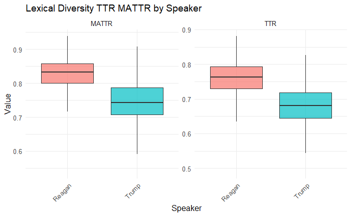

```r
# -----------------------------------------------------
# 1. Reshape data to long format
# -----------------------------------------------------
lex_div_long <- lex_div_df_nostop %>%
  select(speaker, TTR, MATTR) %>%
  pivot_longer(
    cols = c(TTR, MATTR),
    names_to = "measure",
    values_to = "value"
  )

# -----------------------------------------------------
# 2. Boxplot for TTR and MATTR side by side
# -----------------------------------------------------
ggplot(lex_div_long, aes(x = speaker, y = value, fill = speaker)) +
  geom_boxplot(alpha = 0.7, outlier.shape = NA) +
  facet_wrap(~ measure, nrow = 1, scales = "free_y") +
  labs(
    title = "Lexical Diversity TTR MATTR by Speaker",
    x = "Speaker",
    y = "Value"
  ) +
  theme_minimal() +
  theme(
    text = element_text(size = 12),
    legend.position = "none",
    axis.text.x = element_text(angle = 45, hjust = 1)
  )
```

```r
NA
NA
```

#### t.test calculation

```r
# T-test for TTR
ttr_test <- t.test(TTR ~ speaker, data = lex_div_df_nostop)
print(ttr_test)
```

```
    Welch Two Sample t-test

data:  TTR by speaker
t = 30.039, df = 1408.8, p-value < 2.2e-16
alternative hypothesis: true difference in means between group Reagan and group Trump is not equal to 0
95 percent confidence interval:
 0.07284777 0.08302709
sample estimates:
mean in group Reagan  mean in group Trump
           0.7603553            0.6824179
```

```r
# T-test for MATTR
mattr_test <- t.test(MATTR ~ speaker, data = lex_div_df_nostop)
print(mattr_test)
```

```
    Welch Two Sample t-test

data:  MATTR by speaker
t = 30.864, df = 1365.5, p-value < 2.2e-16
alternative hypothesis: true difference in means between group Reagan and group Trump is not equal to 0
95 percent confidence interval:
 0.07721412 0.08769565
sample estimates:
mean in group Reagan  mean in group Trump
           0.8283237            0.7458688
```

# Lemmatize and pos_tag Corpus

We can now move to a more advanced stage of preprocessing by using spacyr, which allows us to perform lemmatization, POS tagging, and other linguistic annotations. First, we verify the structure of our sampled corpus to confirm the number of documents, speakers, and dates. Then, the text is extracted and prepared for parsing. If as.character() fails, a fallback with tokenization ensures that the corpus can still be processed.

```r
library(spacyr)
library(dplyr)

corpus_texts <- as.character(corpus_balanced)
names(corpus_texts) <- docnames(corpus_balanced)

# Fallback (rare, but safe)
if (length(corpus_texts) == 0) {
  corpus_tokens <- tokens(corpus_balanced)
  corpus_texts <- sapply(corpus_tokens, paste, collapse = " ")
  names(corpus_texts) <- names(corpus_tokens)
}


# Uncomment only if needed
# spacy_install()
# spacy_download_langmodel("en_core_web_sm")

spacy_initialize(model = "en_core_web_sm")
chunk_tagged <- spacy_parse(
  corpus_texts,
  lemma      = TRUE,
  pos        = TRUE,
  tag        = TRUE,
  entity     = TRUE,
  dependency = TRUE
)

docvars_df <- data.frame(
  doc_id  = docnames(corpus_balanced),
  speaker = docvars(corpus_balanced, "speaker"),
  date    = docvars(corpus_balanced, "date"),
  stringsAsFactors = FALSE
)

chunk_tagged <- chunk_tagged %>%
  left_join(docvars_df, by = "doc_id")


chunk_tagged %>%
  sample_n(10) %>%
  print()
```

| doc_id | sentence_id | token_id | token | lemma | pos | tag | head_token_id | dep_rel | entity | speaker | date |
| --- | --- | --- | --- | --- | --- | --- | --- | --- | --- | --- | --- |
| 097-5 | 15 | 9 | opponent | opponent | NOUN | NN | 6 | attr |  | Reagan | October 08, 1986 |
| 016-1 | 19 | 16 | compromise | compromise | VERB | VB | 11 | advcl |  | Reagan | March 02, 1982 |
| 057-3 | 24 | 50 | opponent | opponent | NOUN | NN | 48 | dobj |  | Reagan | October 16, 1984 |
| 245-07 | 6 | 8 | of | of | ADP | IN | 7 | prep |  | Trump | February 10, 2020 |
| 065-4 | 24 | 16 | sandinista | sandinista | PROPN | NNP | 17 | compound | NORP_B | Reagan | October 26, 1984 |
| 113-2 | 4 | 15 | reached | reach | VERB | VBD | 5 | advcl |  | Reagan | November 03, 1986 |
| 157-05 | 31 | 35 | things | thing | NOUN | NNS | 33 | dobj |  | Trump | September 21, 2018 |
| 123-4 | 20 | 1 | it | it | PRON | PRP | 2 | nsubj |  | Reagan | October 21, 1988 |
| 258-10 | 35 | 24 | n't | not | PART | RB | 25 | neg |  | Trump | October 18, 2018 |
| 235-05 | 2 | 2 | fact | fact | NOUN | NN | 1 | pobj |  | Trump | August 05, 2022 |

```r
NA
NA
NA
NA
```

### Prepare Lemma corpus

Here we start by checking the structure of the annotated corpus, confirming its columns, speakers, and POS tags. Then we define a small list of unwanted tags (PUNCT, NUM, SYM) and filter them out, leaving only meaningful linguistic elements. Finally, we split the cleaned data into two corpora, one for Reagan and one for Trump, to make speaker-specific comparisons.

```r
remove_pos <- c("PUNCT", "NUM", "SYM")

chunk_clean <- chunk_tagged %>%
  filter(!pos %in% remove_pos)

reagan_clean <- chunk_clean %>%
  filter(speaker == "Reagan")

trump_clean <- chunk_clean %>%
  filter(speaker == "Trump")

lemma_types_per_speaker <- chunk_clean %>%
  group_by(speaker) %>%
  summarise(
    unique_lemmas = n_distinct(lemma)
  )

lemma_types_per_speaker
```

| speaker | unique_lemmas |
| --- | --- |
| Reagan | 8034 |
| Trump | 7109 |

```r
NA
```

### Calculating distributions of POS per Speaker

```r
lemma_tokens_per_speaker <- chunk_clean %>%
  group_by(speaker) %>%
  summarise(
    total_lemmas = n(),
    unique_lemmas = n_distinct(lemma)
  )

lemma_tokens_per_speaker
```

| speaker | total_lemmas | unique_lemmas |
| --- | --- | --- |
| Reagan | 346887 | 8034 |
| Trump | 339822 | 7109 |

```r
library(dplyr)
library(tidyr)

# 1. Define POS categories to keep
pos_keep <- c("NOUN", "PROPN", "VERB", "ADJ", "ADV")

# 2. Filter cleaned, lemmatized data
lemma_pos_summary <- chunk_clean %>%
  filter(pos %in% pos_keep) %>%
  group_by(speaker, pos) %>%
  summarise(
    unique_lemmas = n_distinct(lemma),  # vocabulary size
    total_lemmas  = n(),                # usage frequency
    .groups = "drop"
  ) %>%
  arrange(speaker, pos)

# 3. View the result
print(lemma_pos_summary)
```

| speaker | pos | unique_lemmas | total_lemmas |
| --- | --- | --- | --- |
| Reagan | ADJ | 1548 | 23947 |
| Reagan | ADV | 485 | 18788 |
| Reagan | NOUN | 4208 | 65726 |
| Reagan | PROPN | 1383 | 13658 |
| Reagan | VERB | 1711 | 44801 |
| Trump | ADJ | 1371 | 22748 |
| Trump | ADV | 495 | 19834 |
| Trump | NOUN | 3700 | 53010 |
| Trump | PROPN | 1394 | 13199 |
| Trump | VERB | 1489 | 51924 |

```r
NA
```

### Plotting Distributions

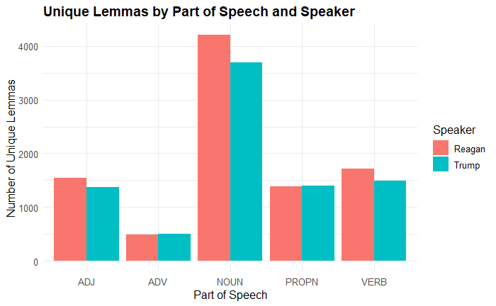

```r
library(ggplot2)

ggplot(lemma_pos_summary,
       aes(x = pos, y = unique_lemmas, fill = speaker)) +
  geom_col(position = "dodge") +
  labs(
    title = "Unique Lemmas by Part of Speech and Speaker",
    x = "Part of Speech",
    y = "Number of Unique Lemmas",
    fill = "Speaker"
  ) +
  theme_minimal() +
  theme(
    text = element_text(size = 12),
    plot.title = element_text(face = "bold")
  )
```

## Lemma-token ratio

We move into measuring lexical variation with the lemma-token ratio (LTR). First, we define a simple function that divides the number of unique lemmas by the total number of tokens. This allows us to estimate how diverse the vocabulary is once words are reduced to their base forms.

```r
library(dplyr)
lemma_ltr <- function(x) {
  length(unique(x$lemma)) / nrow(x)
}

# Reagan: LTR per chunk
reagan_ltr_chunks_df <- reagan_clean %>%
  group_by(doc_id) %>%
  summarise(Lemma_TTR = lemma_ltr(cur_data())) %>%
  ungroup() %>%
  mutate(speaker = "Reagan")
# Trump: LTR per chunk
trump_ltr_chunks_df <- trump_clean %>%
  group_by(doc_id) %>%
  summarise(Lemma_TTR = lemma_ltr(cur_data())) %>%
  ungroup() %>%
  mutate(speaker = "Trump")

# Combine into one table
ltr_chunks_df <- bind_rows(reagan_ltr_chunks_df, trump_ltr_chunks_df)

# Inspect
head(ltr_chunks_df)
```

| doc_id | Lemma_TTR | speaker |
| --- | --- | --- |
| 001-01 | 0.4628821 | Reagan |
| 001-02 | 0.4725275 | Reagan |
| 001-03 | 0.4187082 | Reagan |
| 001-04 | 0.4373576 | Reagan |
| 001-05 | 0.4646226 | Reagan |
| 001-06 | 0.4420131 | Reagan |

```r
NA
```

### Plotting LTR

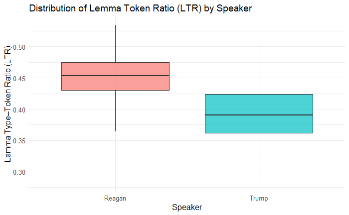

```r
library(ggplot2)

ggplot(ltr_chunks_df, aes(x = speaker, y = Lemma_TTR, fill = speaker)) +
  geom_boxplot(alpha = 0.7, outlier.shape = NA) +
  labs(
    title = "Distribution of Lemma Token Ratio (LTR) by Speaker",
    x = "Speaker",
    y = "Lemma Type–Token Ratio (LTR)"
  ) +
  theme_minimal() +
  theme(
    text = element_text(size = 12),
    legend.position = "none"
  )
```

### Summary Statistics LTR by Speaker

```r
library(dplyr)

# ===============================
# Summary statistics by speaker
# ===============================
ltr_stats <- ltr_chunks_df %>%
  group_by(speaker) %>%
  summarise(
    min_LTR  = min(Lemma_TTR, na.rm = TRUE),
    max_LTR  = max(Lemma_TTR, na.rm = TRUE),
    mean_LTR = mean(Lemma_TTR, na.rm = TRUE),
    sd_LTR   = sd(Lemma_TTR, na.rm = TRUE),
    n_chunks = n(),
    .groups = "drop"
  )

# Inspect
ltr_stats
```

| speaker | min_LTR | max_LTR | mean_LTR | sd_LTR | n_chunks |
| --- | --- | --- | --- | --- | --- |
| Reagan | 0.3562232 | 0.5348837 | 0.4520768 | 0.03351968 | 767 |
| Trump | 0.2813953 | 0.5353319 | 0.3962428 | 0.04779561 | 767 |

```r
NA
```

## Calculation t.test LTR

```r
table(ltr_chunks_df$speaker)
```

```
Reagan  Trump
   767    767
```

```r
summary(ltr_chunks_df$Lemma_TTR)
```

```
   Min. 1st Qu.  Median    Mean 3rd Qu.    Max.
 0.2814  0.3871  0.4273  0.4242  0.4618  0.5353
```

```r
t.test(Lemma_TTR ~ speaker, data = ltr_chunks_df)
```

```
    Welch Two Sample t-test

data:  Lemma_TTR by speaker
t = 26.488, df = 1372.7, p-value < 2.2e-16
alternative hypothesis: true difference in means between group Reagan and group Trump is not equal to 0
95 percent confidence interval:
 0.05169886 0.05996899
sample estimates:
mean in group Reagan  mean in group Trump
           0.4520768            0.3962428
```

```r
library(dplyr)

# ---------------------------------------------
# 1. Prepare LTR data (lemma-based) per chunk
# ---------------------------------------------
lemma_ltr <- function(x) {
  length(unique(x$lemma)) / nrow(x)
}

# Reagan
reagan_ltr_chunks <- reagan_clean %>%
  group_by(doc_id) %>%
  summarise(LTR = lemma_ltr(cur_data())) %>%
  mutate(speaker = "Reagan")

# Trump
trump_ltr_chunks <- trump_clean %>%
  group_by(doc_id) %>%
  summarise(LTR = lemma_ltr(cur_data())) %>%
  mutate(speaker = "Trump")

# Combine speakers
ltr_chunks <- bind_rows(reagan_ltr_chunks, trump_ltr_chunks)

# ---------------------------------------------
# 2. Merge with TTR and MATTR (non-stopwords)
# lex_div_df_nostop must have: doc_id, speaker, TTR, MATTR
# ---------------------------------------------
all_metrics <- lex_div_df_nostop %>%
  select(doc_id, speaker, TTR, MATTR) %>%
  inner_join(ltr_chunks, by = c("doc_id", "speaker"))

# ---------------------------------------------
# 3. Compute correlations
# Overall correlation (all chunks)
# ---------------------------------------------
cor_TTR_LTR_overall   <- cor(all_metrics$TTR, all_metrics$LTR, method = "pearson")
cor_MATTR_LTR_overall <- cor(all_metrics$MATTR, all_metrics$LTR, method = "pearson")

cat("\nOverall correlation:\n")
cat("TTR vs LTR:   ", round(cor_TTR_LTR_overall, 3), "\n")
cat("MATTR vs LTR: ", round(cor_MATTR_LTR_overall, 3), "\n")

# ---------------------------------------------
# 4. Correlations per speaker
# ---------------------------------------------
speaker_corrs <- all_metrics %>%
  group_by(speaker) %>%
  summarise(
    cor_TTR_LTR   = cor(TTR, LTR, method = "pearson"),
    cor_MATTR_LTR = cor(MATTR, LTR, method = "pearson")
  )

cat("\nPer-speaker correlations:\n")
print(speaker_corrs)
```

[output not shown]

# Kogomorov Overall Complexity:

Kolmogorov complexity is a concept from information theory that measures the “compressibility” of a text—that is, the length of the shortest possible description (or program) that can reproduce it. In practice, highly predictable or repetitive texts are more compressible, while complex or less redundant texts are less compressible. The next code below estimates this idea by comparing the original size of each speech (in bytes) with its compressed size using gzip compression. By doing so, it provides a numeric proxy for informational complexity: smaller compressed sizes indicate more predictable or repetitive language, while larger compressed sizes suggest richer, more varied linguistic structure. The code also organizes the results by speaker and allows sampling for further analysis or visualization.

```r
# Compute original size (in bytes) and compressed size
balanced_df <- balanced_df %>%
  mutate(
    original_size   = nchar(text, type = "bytes"),          # original size in bytes
    compressed_size = sapply(text, function(txt) {
      length(memCompress(charToRaw(txt), type = "gzip"))   # compressed size in bytes
    })
  )




# Create a new dataframe with speaker, original size, and compressed size
compression_df <- balanced_df %>%
  select(unique_id, speaker, original_size, compressed_size)

set.seed(123)
compression_df %>%
  group_by(speaker) %>%
  sample_n(2) %>%   # 2 per speaker (adjust as needed)
  ungroup()
```

| unique_id | speaker | original_size | compressed_size |
| --- | --- | --- | --- |
| 073-5 | Reagan | 2569 | 1167 |
| 046-3 | Reagan | 2619 | 1225 |
| 172-12 | Trump | 2565 | 1142 |
| 206-01 | Trump | 2638 | 1206 |

```r
NA
```

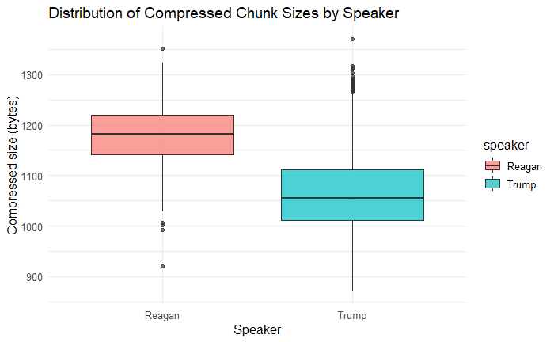

```r
ggplot(compression_df, aes(x = speaker, y = compressed_size, fill = speaker)) +
  geom_boxplot(alpha = 0.7) +
  labs(
    title = "Distribution of Compressed Chunk Sizes by Speaker",
    x = "Speaker",
    y = "Compressed size (bytes)"
  ) +
  theme_minimal() +
  theme(text = element_text(size = 12))
```

```r
NA
NA
```

the compression size shows that Reagan chunks has higher compresion sizes, however this can be sensitive to the representation of bytes of the chunks.The next code extends the compression-based approach to measure linguistic complexity by considering both text length and byte representation. Overall complexity is first calculated as the proportion of the original text size (in bytes) that is compressible, capturing how predictable or redundant the text is. Because longer texts—or texts with more byte-heavy characters—naturally produce larger compressed sizes, a simple compression ratio can be biased. To correct for this, the code fits a linear regression of compressed size on original size (in bytes) and extracts the residuals as adjusted overall complexity. These residuals provide a measure of structural complexity that is independent of text length and byte size, enabling fair comparisons across speeches of different lengths and character encodings. Finally, distributions and summaries are computed to explore variability in complexity across speakers.

```r
library(dplyr)

compression_df <- compression_df %>%
  mutate(
    overall_complexity = (original_size - compressed_size) / original_size
  )

# Inspect
head(compression_df)
```

| unique_id | speaker | original_size | compressed_size | overall_complexity |
| --- | --- | --- | --- | --- |
| 074-4 | Reagan | 2547 | 1187 | 0.5339615 |
| 082-3 | Reagan | 2465 | 1121 | 0.5452333 |
| 032-3 | Reagan | 2491 | 1115 | 0.5523886 |
| 097-2 | Reagan | 2524 | 1153 | 0.5431854 |
| 036-1 | Reagan | 2420 | 1168 | 0.5173554 |
| 021-3 | Reagan | 2633 | 1257 | 0.5225978 |

```r
library(ggplot2)


library(dplyr)

# Fit linear regression: compressed_size ~ original_size
compression_lm <- lm(compressed_size ~ original_size, data = compression_df)

# Extract residuals as adjusted overall complexity
compression_df <- compression_df %>%
  mutate(
    adjusted_overall_complexity = resid(compression_lm)
  )

# Inspect
head(compression_df)
```

| unique_id | speaker | original_size | compressed_size | overall_complexity | adjusted_overall_complexity |
| --- | --- | --- | --- | --- | --- |
| 074-4 | Reagan | 2547 | 1187 | 0.5339615 | 30.626065 |
| 082-3 | Reagan | 2465 | 1121 | 0.5452333 | 15.678810 |
| 032-3 | Reagan | 2491 | 1115 | 0.5523886 | -6.508646 |
| 097-2 | Reagan | 2524 | 1153 | 0.5431854 | 10.945737 |
| 036-1 | Reagan | 2420 | 1168 | 0.5173554 | 90.695561 |
| 021-3 | Reagan | 2633 | 1257 | 0.5225978 | 47.082941 |

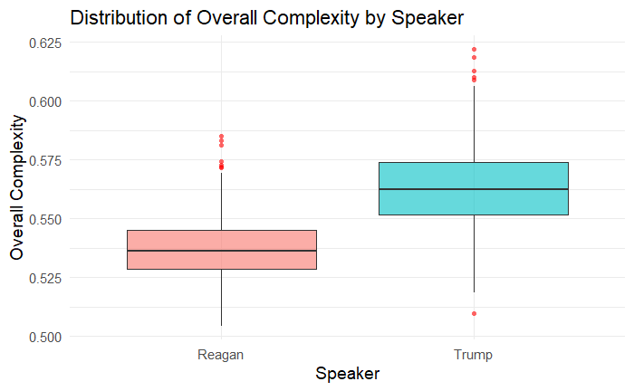

```r
ggplot(compression_df, aes(x = speaker, y = overall_complexity, fill = speaker)) +
  geom_boxplot(outlier.colour = "red", outlier.shape = 16, alpha = 0.6) +
  labs(
    title = "Distribution of Overall Complexity by Speaker",
    x = "Speaker",
    y = "Overall Complexity"
  ) +
  theme_minimal(base_size = 14) +
  theme(legend.position = "none")
```

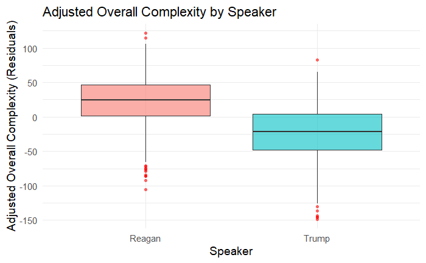

```r
library(ggplot2)

ggplot(compression_df, aes(x = speaker, y = adjusted_overall_complexity, fill = speaker)) +
  geom_boxplot(outlier.colour = "red", outlier.shape = 16, alpha = 0.6) +
  labs(
    title = "Adjusted Overall Complexity by Speaker",
    x = "Speaker",
    y = "Adjusted Overall Complexity (Residuals)"
  ) +
  theme_minimal(base_size = 14) +
  theme(legend.position = "none")
```

```r
library(dplyr)

compression_summary <- compression_df %>%
  group_by(speaker) %>%
  summarise(
    # Original overall complexity
    mean_overall      = mean(overall_complexity, na.rm = TRUE),
    sd_overall        = sd(overall_complexity, na.rm = TRUE),
    min_overall       = min(overall_complexity, na.rm = TRUE),
    max_overall       = max(overall_complexity, na.rm = TRUE),

    # Adjusted overall complexity
    mean_adjusted     = mean(adjusted_overall_complexity, na.rm = TRUE),
    sd_adjusted       = sd(adjusted_overall_complexity, na.rm = TRUE),
    min_adjusted      = min(adjusted_overall_complexity, na.rm = TRUE),
    max_adjusted      = max(adjusted_overall_complexity, na.rm = TRUE),

    n_chunks          = n()
  )

print(compression_summary)
```

| speaker | mean_overall | sd_overall | min_overall | max_overall | mean_adjusted | sd_adjusted | min_adjusted | max_adjusted | n_chunks |
| --- | --- | --- | --- | --- | --- | --- | --- | --- | --- |
| Reagan | 0.5371837 | 0.01246187 | 0.5044462 | 0.5850248 | 22.28018 | 34.65242 | -105.1263 | 121.41188 | 767 |
| Trump | 0.5627503 | 0.01669995 | 0.5097291 | 0.6218669 | -22.28018 | 38.43232 | -148.6074 | 82.55407 | 767 |

```r
NA
```

Calculation t.test() overall adjusted complexity

```r
# Two-sample Welch's t-test for adjusted Kolmogorov complexity
t.test(adjusted_overall_complexity ~ speaker, data = compression_df)
```

```
    Welch Two Sample t-test

data:  adjusted_overall_complexity by speaker
t = 23.848, df = 1515.9, p-value < 2.2e-16
alternative hypothesis: true difference in means between group Reagan and group Trump is not equal to 0
95 percent confidence interval:
 40.89524 48.22549
sample estimates:
mean in group Reagan  mean in group Trump
            22.28018            -22.28018
```

## Kolmogorov Syntatic complexity

To estimate syntactic complexity, we apply a distortion-and-compression procedure that randomly removes a proportion of tokens from each text and measures the resulting compressed size. This process is repeated multiple times and the average compressed size is recorded.Texts with highly structured, repetitive, and dependent syntactic patterns—such as nested clauses or recurring function-word sequences—are more affected by token removal because their internal redundancy is disrupted, leading to larger compressed sizes. In contrast, texts with looser or less predictable structures are less sensitive to token removal. This approach allows us to quantify syntactic complexity in a way that goes beyond surface length, capturing the degree to which a text’s organization relies on predictable, interdependent structures.

```r
# Function with iterations
syntactic_distortion_size_iter <- function(text, remove_prop = 0.10, n_iter = 100) {

  tokens <- unlist(strsplit(text, "\\s+"))

  # Safety check
  if (length(tokens) < 10) return(NA)

  n_remove <- ceiling(remove_prop * length(tokens))

  # Run the distortion + compression multiple times
  compressed_sizes <- numeric(n_iter)

  for (i in 1:n_iter) {
    distorted_tokens <- tokens[-sample(seq_along(tokens), n_remove)]
    distorted_text <- paste(distorted_tokens, collapse = " ")
    compressed_sizes[i] <- length(memCompress(charToRaw(distorted_text), type = "gzip"))
  }

  # Return the mean compressed size over all iterations
  mean(compressed_sizes)
}

set.seed(123)

# Apply to all chunks
balanced_df$syntactic_compressed_size <- vapply(
  balanced_df$text,
  syntactic_distortion_size_iter,
  numeric(1),
  remove_prop = 0.10,
  n_iter = 100
)

# Original compressed size function (unchanged)
original_compressed_size <- function(text) {
  length(memCompress(charToRaw(text), type = "gzip"))
}

balanced_df$original_compressed_size <- vapply(
  balanced_df$text,
  original_compressed_size,
  numeric(1)
)

# Calculate syntactic complexity
balanced_df$syntactic_complexity <-
  balanced_df$syntactic_compressed_size /
  balanced_df$original_compressed_size

# Summary by speaker
library(dplyr)

balanced_df %>%
  group_by(speaker) %>%
  summarise(
    n_chunks = n(),
    avg_syntactic_complexity = mean(syntactic_complexity, na.rm = TRUE),
    sd_syntactic_complexity  = sd(syntactic_complexity, na.rm = TRUE),
    min_syntactic_complexity = min(syntactic_complexity, na.rm = TRUE),
    max_syntactic_complexity = max(syntactic_complexity, na.rm = TRUE)
  )
```

| speaker | n_chunks | avg_syntactic_complexity | sd_syntactic_complexity | min_syntactic_complexity | max_syntactic_complexity |
| --- | --- | --- | --- | --- | --- |
| Reagan | 767 | 0.9181630 | 0.004016595 | 0.9086018 | 0.9442500 |
| Trump | 767 | 0.9272046 | 0.006059514 | 0.9078288 | 0.9484114 |

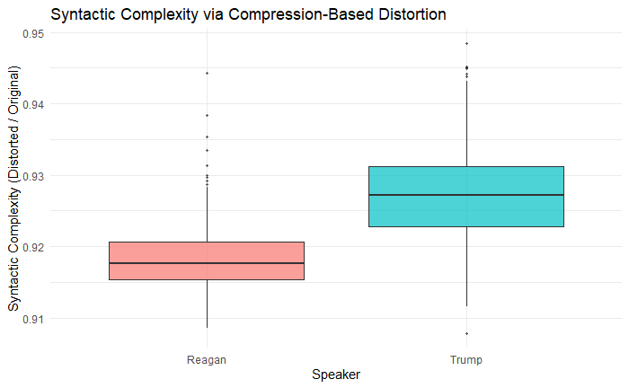

```r
#  plot boxplots
library(ggplot2)

ggplot(balanced_df, aes(x = speaker, y = syntactic_complexity, fill = speaker)) +
  geom_boxplot(alpha = 0.7, outlier.size = 0.8) +
  labs(
    title = "Syntactic Complexity via Compression-Based Distortion",
    x = "Speaker",
    y = "Syntactic Complexity (Distorted / Original)"
  ) +
  theme_minimal() +
  theme(legend.position = "none")
```

### Calculation t.test() Sytactic Complextiy

```r
# Extract syntactic complexity values by speaker
reagan_complexity <- balanced_df$syntactic_complexity[balanced_df$speaker == "Reagan"]
trump_complexity  <- balanced_df$syntactic_complexity[balanced_df$speaker == "Trump"]

# Run Kolmogorov–Smirnov test
t_syntactic <- t.test(reagan_complexity, trump_complexity)
t_syntactic
```

```
    Welch Two Sample t-test

data:  reagan_complexity and trump_complexity
t = -34.444, df = 1330.2, p-value < 2.2e-16
alternative hypothesis: true difference in means is not equal to 0
95 percent confidence interval:
 -0.009556495 -0.008526580
sample estimates:
mean of x mean of y
0.9181630 0.9272046
```

#Morphologhical

To estimate morphological complexity, we apply a distortion-and-compression method at the character level. For each text, a proportion of characters (0.10) is randomly removed, and the resulting text is compressed; this process is repeated multiple times and the average compressed size is recorded. Texts with simpler morphologically word forms—lose more structural information when characters are removed, producing larger compressed sizes. In contrast, texts with more complex morphology are less sensitive to random character removal. This approach allows us to quantify the degree of morphological redundancy and structural regularity in a text, complementing syntactic and lexical complexity measures to provide a more holistic picture of linguistic organization in campaign speeches.

```r
morphological_distortion_size_iter <- function(text, remove_prop = 0.10, n_iter = 100) {

  chars <- unlist(strsplit(text, ""))

  # Safety check
  if (length(chars) < 50) return(NA)

  n_remove <- ceiling(remove_prop * length(chars))

  compressed_sizes <- numeric(n_iter)

  for (i in 1:n_iter) {
    distorted_chars <- chars[-sample(seq_along(chars), n_remove)]
    distorted_text <- paste(distorted_chars, collapse = "")
    compressed_sizes[i] <- length(
      memCompress(charToRaw(distorted_text), type = "gzip")
    )
  }

  # Mean compressed size across iterations
  mean(compressed_sizes)
}
set.seed(123)

balanced_df$morphological_compressed_size <- vapply(
  balanced_df$text,
  morphological_distortion_size_iter,
  numeric(1),
  remove_prop = 0.10,
  n_iter = 100
)
```

```r
balanced_df$morphological_complexity <-
  - balanced_df$morphological_compressed_size /
  balanced_df$original_compressed_size
```

```r
library(dplyr)

balanced_df %>%
  group_by(speaker) %>%
  summarise(
    n_chunks = n(),
    avg_morphological_complexity = mean(morphological_complexity, na.rm = TRUE),
    sd_morphological_complexity  = sd(morphological_complexity, na.rm = TRUE),
    min_morphological_complexity = min(morphological_complexity, na.rm = TRUE),
    max_morphological_complexity = max(morphological_complexity, na.rm = TRUE)
  )
```

| speaker | n_chunks | avg_morphological_complexity | sd_morphological_complexity | min_morphological_complexity | max_morphological_complexity |
| --- | --- | --- | --- | --- | --- |
| Reagan | 767 | -0.9911964 | 0.01326681 | -1.053860 | -0.9601987 |
| Trump | 767 | -1.0224968 | 0.01994147 | -1.102766 | -0.9606148 |

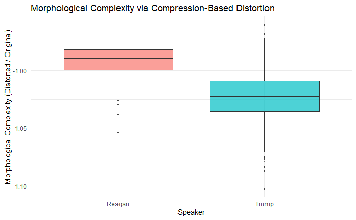

```r
library(ggplot2)

ggplot(balanced_df, aes(x = speaker, y = morphological_complexity, fill = speaker)) +
  geom_boxplot(alpha = 0.7, outlier.size = 0.8) +
  labs(
    title = "Morphological Complexity via Compression-Based Distortion",
    x = "Speaker",
    y = "Morphological Complexity (Distorted / Original)"
  ) +
  theme_minimal() +
  theme(legend.position = "none")
```

### Calcaulatin t.test() Morphological Complexity

```r
# Extract morphological  complexity ratios by speaker
reagan_complexity_m <- balanced_df$morphological_complexity[balanced_df$speaker == "Reagan"]
trump_complexity_m  <- balanced_df$morphological_complexity[balanced_df$speaker == "Trump"]

# Run Kolmogorov–Smirnov test
t_morphologhical <- t.test(reagan_complexity_m, trump_complexity_m)
t_morphologhical
```

```
    Welch Two Sample t-test

data:  reagan_complexity_m and trump_complexity_m
t = 36.192, df = 1333, p-value < 2.2e-16
alternative hypothesis: true difference in means is not equal to 0
95 percent confidence interval:
 0.02960376 0.03299693
sample estimates:
 mean of x  mean of y
-0.9911964 -1.0224968
```

### Correlation MATRIX

Using Pearson correlation it is possible to see the realtionships between the scores first it is necessary to merge all results into a single data frame by chunk id. first TRR and MATTR with complexity measures

```r
library(dplyr)

# Keep only the relevant columns from lex_div_df_nostop
lex_div_subset <- lex_div_df_nostop %>%
  select(doc_id, TTR, MATTR)

# Join TTR & MATTR into balanced_df by matching doc_id → unique_id
balanced_df <- balanced_df %>%
  left_join(lex_div_subset, by = c("unique_id" = "doc_id"))


# Check
head(balanced_df)
```

| unique_id | text | original_doc | speaker | title | date | link | ntokens | original_size | compressed_size | syntactic_compressed_size | original_compressed_size | syntactic_complexity | contains_reagan | contains_trump | morphological_compressed_size | morphological_complexity | TTR | MATTR |
| --- | --- | --- | --- | --- | --- | --- | --- | --- | --- | --- | --- | --- | --- | --- | --- | --- | --- | --- |
| 074-4 | . in those days when i was a democrat , the leaders of the democratic party weren't members of that " blame america first " crowd . it's leaders were men like harry truman and , later , men like senat… | 074 | Reagan | Remarks at a Reagan-Bush Rally in Saginaw, Michigan | November 02, 1984 | https://www.presidency.ucsb.edu/documents/remarks-reagan-bush-rally-saginaw-michigan | 442 | 2547 | 1187 | 1086.81 | 1187 | 0.9155939 | FALSE | FALSE | 1167.68 | -0.9837237 | 0.7863636 | 0.8324793 |
| 082-3 | increases . all right . you talked me into it . all right . you know , if my opponent's campaign were a television show , it would be " let's make a deal . " you give up your prosperity to get his sur… | 082 | Reagan | Remarks at a Reagan-Bush Rally in Van Nuys, California | November 05, 1984 | https://www.presidency.ucsb.edu/documents/remarks-reagan-bush-rally-van-nuys-california | 421 | 2465 | 1121 | 1039.15 | 1121 | 0.9269848 | FALSE | FALSE | 1129.75 | -1.0078055 | 0.7219512 | 0.7500000 |
| 032-3 | year . you know , when you start to talk about the facts , the fog really lifts . and when the fog lifts you can see the country the way it really is . now , i'm not talking about big statistics that … | 032 | Reagan | Remarks at a Reagan-Bush Rally in Atlanta, Georgia | July 26, 1984 | https://www.presidency.ucsb.edu/documents/remarks-reagan-bush-rally-atlanta-georgia | 435 | 2491 | 1115 | 1023.28 | 1115 | 0.9177399 | FALSE | FALSE | 1120.23 | -1.0046906 | 0.7187500 | 0.7631183 |
| 097-2 | this morning — good to leave behind the big government and special interests of washington — to come here to atlanta and the real america : the america of hard work , patriotism , and the kind of peac… | 097 | Reagan | Remarks at a Campaign Rally for Senator Mack Mattingly in Atlanta, Georgia | October 08, 1986 | https://www.presidency.ucsb.edu/documents/remarks-campaign-rally-for-senator-mack-mattingly-atlanta-georgia | 457 | 2524 | 1153 | 1058.11 | 1153 | 0.9177016 | FALSE | FALSE | 1148.37 | -0.9959844 | 0.7330317 | 0.7854918 |
| 036-1 | thank you all very much . well , i have to tell you , i like that sound . maybe i shouldn't say anything . i should take billy joel's advice — you know that fine young singer from new york . he said ,… | 036 | Reagan | Remarks at a Reagan-Bush Welcoming Rally at the Republican National Convention in Dallas, Texas | August 22, 1984 | https://www.presidency.ucsb.edu/documents/remarks-reagan-bush-welcoming-rally-the-republican-national-convention-dallas-texas | 432 | 2420 | 1168 | 1065.08 | 1168 | 0.9118836 | TRUE | FALSE | 1135.73 | -0.9723716 | 0.7874396 | 0.8941667 |
| 021-3 | concern to peorians right now . we're receptive to alternative measures that would be equally or more effective than the current sanctions . certainly , if we can establish restrictions that put great… | 021 | Reagan | Remarks at an Illinois Republican Party Rally in Peoria | October 20, 1982 | https://www.presidency.ucsb.edu/documents/remarks-illinois-republican-party-rally-peoria | 441 | 2633 | 1257 | 1152.23 | 1257 | 0.9166508 | FALSE | FALSE | 1232.93 | -0.9808512 | 0.8229665 | 0.8750000 |

```r
library(dplyr)

# Merge the complexity scores into balanced_df
balanced_df <- balanced_df %>%
  left_join(
    compression_df %>%
      select(unique_id, overall_complexity, adjusted_overall_complexity),
    by = c("unique_id")
  )

# Check the first rows to confirm
head(balanced_df)
```

| unique_id | text | original_doc | speaker | title | date | link | ntokens | original_size | compressed_size | syntactic_compressed_size | original_compressed_size | syntactic_complexity | contains_reagan | contains_trump | morphological_compressed_size | morphological_complexity | TTR | MATTR | overall_complexity | adjusted_overall_complexity |
| --- | --- | --- | --- | --- | --- | --- | --- | --- | --- | --- | --- | --- | --- | --- | --- | --- | --- | --- | --- | --- |
| 074-4 | . in those days when i was a democrat , the leaders of the democratic party weren't members of that " blame america first " crowd . it's leaders were men like harry truman and , later , men like senat… | 074 | Reagan | Remarks at a Reagan-Bush Rally in Saginaw, Michigan | November 02, 1984 | https://www.presidency.ucsb.edu/documents/remarks-reagan-bush-rally-saginaw-michigan | 442 | 2547 | 1187 | 1086.81 | 1187 | 0.9155939 | FALSE | FALSE | 1167.68 | -0.9837237 | 0.7863636 | 0.8324793 | 0.5339615 | 30.626065 |
| 082-3 | increases . all right . you talked me into it . all right . you know , if my opponent's campaign were a television show , it would be " let's make a deal . " you give up your prosperity to get his sur… | 082 | Reagan | Remarks at a Reagan-Bush Rally in Van Nuys, California | November 05, 1984 | https://www.presidency.ucsb.edu/documents/remarks-reagan-bush-rally-van-nuys-california | 421 | 2465 | 1121 | 1039.15 | 1121 | 0.9269848 | FALSE | FALSE | 1129.75 | -1.0078055 | 0.7219512 | 0.7500000 | 0.5452333 | 15.678810 |
| 032-3 | year . you know , when you start to talk about the facts , the fog really lifts . and when the fog lifts you can see the country the way it really is . now , i'm not talking about big statistics that … | 032 | Reagan | Remarks at a Reagan-Bush Rally in Atlanta, Georgia | July 26, 1984 | https://www.presidency.ucsb.edu/documents/remarks-reagan-bush-rally-atlanta-georgia | 435 | 2491 | 1115 | 1023.28 | 1115 | 0.9177399 | FALSE | FALSE | 1120.23 | -1.0046906 | 0.7187500 | 0.7631183 | 0.5523886 | -6.508646 |
| 097-2 | this morning — good to leave behind the big government and special interests of washington — to come here to atlanta and the real america : the america of hard work , patriotism , and the kind of peac… | 097 | Reagan | Remarks at a Campaign Rally for Senator Mack Mattingly in Atlanta, Georgia | October 08, 1986 | https://www.presidency.ucsb.edu/documents/remarks-campaign-rally-for-senator-mack-mattingly-atlanta-georgia | 457 | 2524 | 1153 | 1058.11 | 1153 | 0.9177016 | FALSE | FALSE | 1148.37 | -0.9959844 | 0.7330317 | 0.7854918 | 0.5431854 | 10.945737 |
| 036-1 | thank you all very much . well , i have to tell you , i like that sound . maybe i shouldn't say anything . i should take billy joel's advice — you know that fine young singer from new york . he said ,… | 036 | Reagan | Remarks at a Reagan-Bush Welcoming Rally at the Republican National Convention in Dallas, Texas | August 22, 1984 | https://www.presidency.ucsb.edu/documents/remarks-reagan-bush-welcoming-rally-the-republican-national-convention-dallas-texas | 432 | 2420 | 1168 | 1065.08 | 1168 | 0.9118836 | TRUE | FALSE | 1135.73 | -0.9723716 | 0.7874396 | 0.8941667 | 0.5173554 | 90.695561 |
| 021-3 | concern to peorians right now . we're receptive to alternative measures that would be equally or more effective than the current sanctions . certainly , if we can establish restrictions that put great… | 021 | Reagan | Remarks at an Illinois Republican Party Rally in Peoria | October 20, 1982 | https://www.presidency.ucsb.edu/documents/remarks-illinois-republican-party-rally-peoria | 441 | 2633 | 1257 | 1152.23 | 1257 | 0.9166508 | FALSE | FALSE | 1232.93 | -0.9808512 | 0.8229665 | 0.8750000 | 0.5225978 | 47.082941 |

```r
NA
NA
```

Then LTR scores

```r
library(dplyr)

# Assuming ltr_chunks_df has columns: doc_id, Lemma_TTR, speaker
# Merge LTR into balanced_df
balanced_df <- balanced_df %>%
  left_join(
    ltr_chunks_df %>% select(doc_id, Lemma_TTR),
    by = c("unique_id" = "doc_id")
  )

# Check the first rows
head(balanced_df)
```

| unique_id | text | original_doc | speaker | title | date | link | ntokens | original_size | compressed_size | syntactic_compressed_size | original_compressed_size | syntactic_complexity | contains_reagan | contains_trump | morphological_compressed_size | morphological_complexity | TTR | MATTR | overall_complexity | adjusted_overall_complexity | Lemma_TTR |
| --- | --- | --- | --- | --- | --- | --- | --- | --- | --- | --- | --- | --- | --- | --- | --- | --- | --- | --- | --- | --- | --- |
| 074-4 | . in those days when i was a democrat , the leaders of the democratic party weren't members of that " blame america first " crowd . it's leaders were men like harry truman and , later , men like senat… | 074 | Reagan | Remarks at a Reagan-Bush Rally in Saginaw, Michigan | November 02, 1984 | https://www.presidency.ucsb.edu/documents/remarks-reagan-bush-rally-saginaw-michigan | 442 | 2547 | 1187 | 1086.81 | 1187 | 0.9155939 | FALSE | FALSE | 1167.68 | -0.9837237 | 0.7863636 | 0.8324793 | 0.5339615 | 30.626065 | 0.4701987 |
| 082-3 | increases . all right . you talked me into it . all right . you know , if my opponent's campaign were a television show , it would be " let's make a deal . " you give up your prosperity to get his sur… | 082 | Reagan | Remarks at a Reagan-Bush Rally in Van Nuys, California | November 05, 1984 | https://www.presidency.ucsb.edu/documents/remarks-reagan-bush-rally-van-nuys-california | 421 | 2465 | 1121 | 1039.15 | 1121 | 0.9269848 | FALSE | FALSE | 1129.75 | -1.0078055 | 0.7219512 | 0.7500000 | 0.5452333 | 15.678810 | 0.4638695 |
| 032-3 | year . you know , when you start to talk about the facts , the fog really lifts . and when the fog lifts you can see the country the way it really is . now , i'm not talking about big statistics that … | 032 | Reagan | Remarks at a Reagan-Bush Rally in Atlanta, Georgia | July 26, 1984 | https://www.presidency.ucsb.edu/documents/remarks-reagan-bush-rally-atlanta-georgia | 435 | 2491 | 1115 | 1023.28 | 1115 | 0.9177399 | FALSE | FALSE | 1120.23 | -1.0046906 | 0.7187500 | 0.7631183 | 0.5523886 | -6.508646 | 0.3960177 |
| 097-2 | this morning — good to leave behind the big government and special interests of washington — to come here to atlanta and the real america : the america of hard work , patriotism , and the kind of peac… | 097 | Reagan | Remarks at a Campaign Rally for Senator Mack Mattingly in Atlanta, Georgia | October 08, 1986 | https://www.presidency.ucsb.edu/documents/remarks-campaign-rally-for-senator-mack-mattingly-atlanta-georgia | 457 | 2524 | 1153 | 1058.11 | 1153 | 0.9177016 | FALSE | FALSE | 1148.37 | -0.9959844 | 0.7330317 | 0.7854918 | 0.5431854 | 10.945737 | 0.4233261 |
| 036-1 | thank you all very much . well , i have to tell you , i like that sound . maybe i shouldn't say anything . i should take billy joel's advice — you know that fine young singer from new york . he said ,… | 036 | Reagan | Remarks at a Reagan-Bush Welcoming Rally at the Republican National Convention in Dallas, Texas | August 22, 1984 | https://www.presidency.ucsb.edu/documents/remarks-reagan-bush-welcoming-rally-the-republican-national-convention-dallas-texas | 432 | 2420 | 1168 | 1065.08 | 1168 | 0.9118836 | TRUE | FALSE | 1135.73 | -0.9723716 | 0.7874396 | 0.8941667 | 0.5173554 | 90.695561 | 0.4557522 |
| 021-3 | concern to peorians right now . we're receptive to alternative measures that would be equally or more effective than the current sanctions . certainly , if we can establish restrictions that put great… | 021 | Reagan | Remarks at an Illinois Republican Party Rally in Peoria | October 20, 1982 | https://www.presidency.ucsb.edu/documents/remarks-illinois-republican-party-rally-peoria | 441 | 2633 | 1257 | 1152.23 | 1257 | 0.9166508 | FALSE | FALSE | 1232.93 | -0.9808512 | 0.8229665 | 0.8750000 | 0.5225978 | 47.082941 | 0.4803493 |

```r
NA
```

### Applying Pearson Correlation and Visualize it

```r
library(dplyr)
library(corrplot)
# Select only the relevant numeric columns
correlation_df <- balanced_df %>%
  select(Lemma_TTR, TTR, MATTR, adjusted_overall_complexity,
         syntactic_complexity, morphological_complexity)

# Calculate correlation matrix
cor_matrix <- cor(correlation_df, use = "pairwise.complete.obs", method = "pearson")

# Print correlation matrix
print(cor_matrix)
```

```
                             Lemma_TTR        TTR      MATTR adjusted_overall_complexity syntactic_complexity
Lemma_TTR                    1.0000000  0.8542527  0.8429653                   0.5323275           -0.7935079
TTR                          0.8542527  1.0000000  0.9273168                   0.6449815           -0.8189093
MATTR                        0.8429653  0.9273168  1.0000000                   0.6081232           -0.8162802
adjusted_overall_complexity  0.5323275  0.6449815  0.6081232                   1.0000000           -0.7095737
syntactic_complexity        -0.7935079 -0.8189093 -0.8162802                  -0.7095737            1.0000000
morphological_complexity     0.8316601  0.8836557  0.8608950                   0.8288612           -0.9518331
                            morphological_complexity
Lemma_TTR                                  0.8316601
TTR                                        0.8836557
MATTR                                      0.8608950
adjusted_overall_complexity                0.8288612
syntactic_complexity                      -0.9518331
morphological_complexity                   1.0000000
```

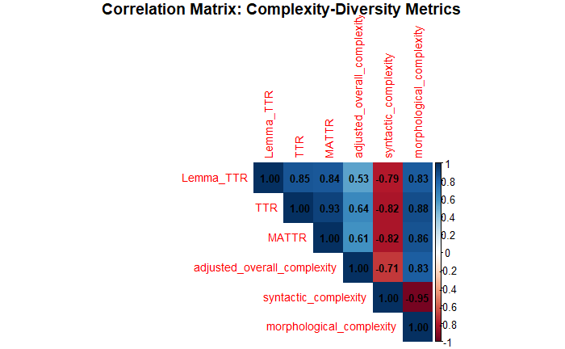

```r
#  visualize it
corrplot::corrplot(cor_matrix, method = "color", type = "upper",
                   addCoef.col = "black", tl.cex = 0.9, number.cex = 0.8,
                   title = "Correlation Matrix: Complexity-Diversity Metrics", mar=c(0,0,1,0))
```

```r
NA
NA
NA
```